# Cohen_TCGA_colon_profiles

Jonas BEAL

15/01/2019

## Set up

We set the paths to the folders

## Objectives

Generate patients profiles from colorectal TCGA data for further logical modelling.

## Import data

### TCGA dataset recap

Available omics data: mutations, Copy Number Alterations (CNA), RNA, proteomics and clinical annotations.

Due to inconsistencies in genes names (DEC1 replaced by 1-Dec for instance), Entrez ID are used to recover proper HUGO names. Import HUGO/Entrez table for later quality check

Some tables have to be transposed

Different data types are imported:

- TCGA colon clinical data
- TCGA mutation data
- TCGA CNA data
- TCGA RNA data

### The model

Restrict the analysis to the genes of the logical model. Note that it is important to set up a document with name correspondence and carefully verify the names of the model (case-sensitive!) and their corresponding HUGO name

## Visualize the available data

Most patients have all omics data, see below the number of available patients for each combination of omics:

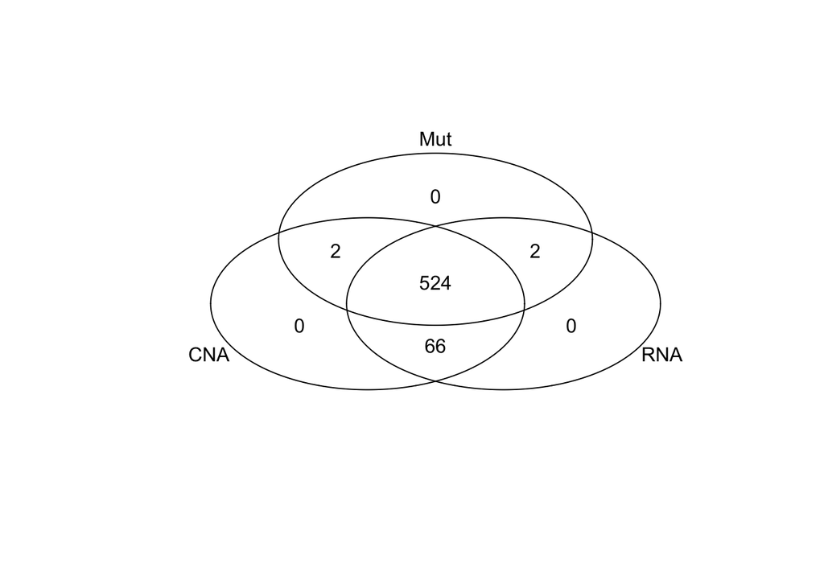

Are model genes represented in omics data? See below the number of common genes in the model and in the different omics layers:

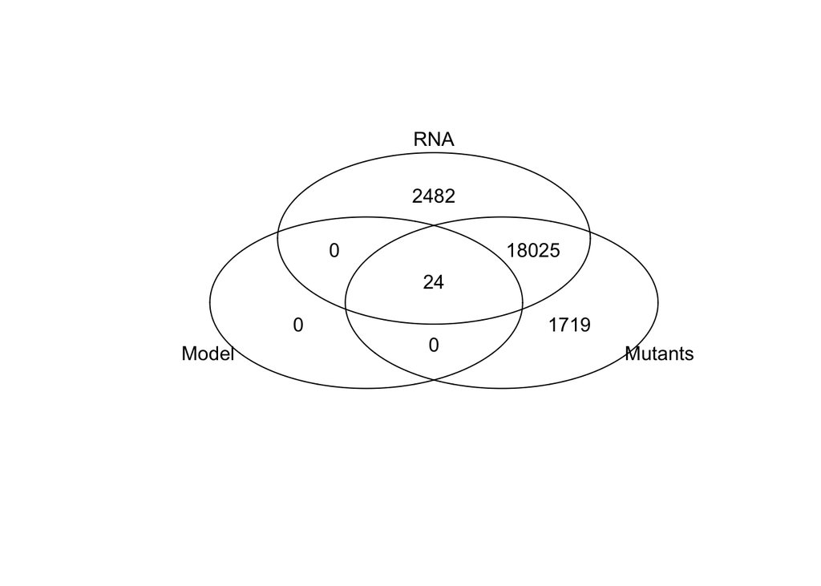

## Processing pipeline

Please note that most of the following computations are performed on all available genes and not model-related genes in order to provide a broader description of processing effect on a global scale. For the purpose of pure simulations of logical models without preliminary analysis, it is possible to focus on model-related genes without changing results.

### Create mutations profiles

We need to assign Boolean effects to mutations: either 0 (inactivating) or 1 (activating). A mutation can stay unassigned in absence of any evidence.

Visualize the assignement methods and their respective influence:

```
## [1] "Sankey plots of mutation assignments depending on methods used"
```

[interactive chart not shown]

```
## [1] "Sankey plots of mutation assignments depending on methods used (restricted to model-related nodes)"
```

[interactive chart not shown]

Now we can summarize patient mutation profiles after processing. In the following plots, we focus on model-related genes only.

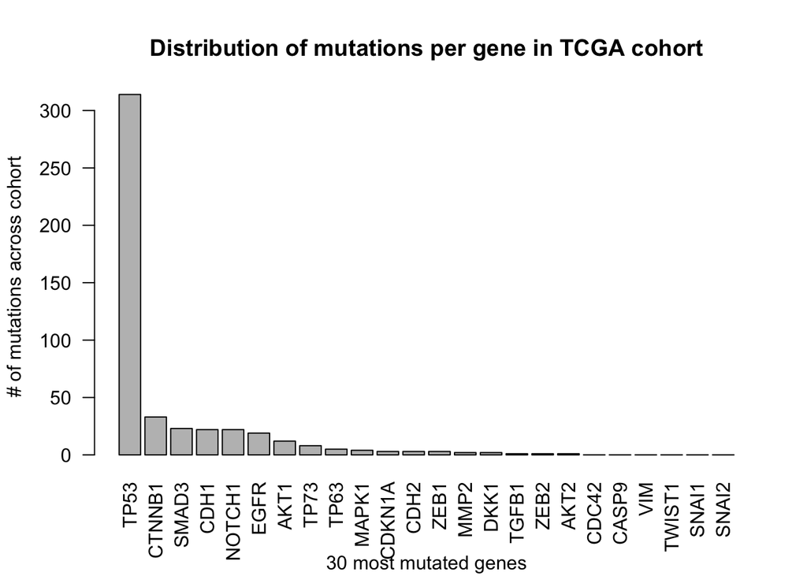

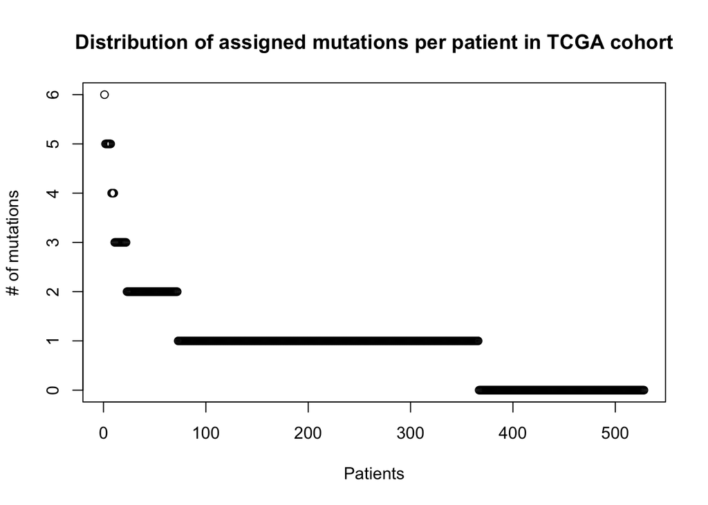

### Create CNA profiles

For CNA, we have decided to focus on stringent amplifications/deletions corresponding to +2/-2 GISTIC results. We produce the same kind of plots.

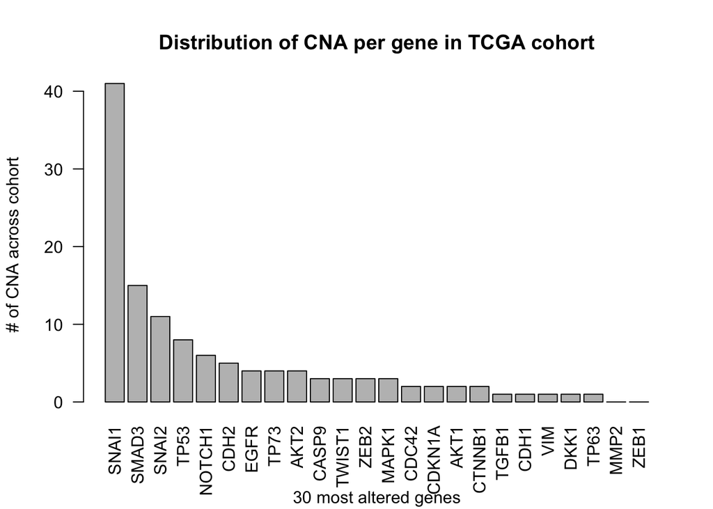

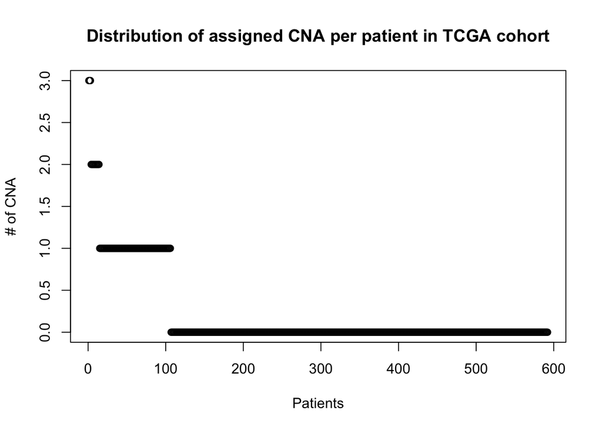

### Create RNA profiles

RNA data is intrinsically continuous and therefore require preliminary data processing. It is important to notice that these TCGA data are RNAseq data. In order to provide a comprehensive description, by default all genes are processed/categorized. To save some time it is possible to restrit this computation for model-related genes only.

#### Binarization with classification tree

### Create RNA profile criteria

Visualize the distribution of gene categories (Bimodal, Unimodal…) across the cohort

```
## [1] "TCGA assignments:"
```

| Bimodal | Discarded | Unimodal | ZeroInf |
| --- | --- | --- | --- |
| 152 | 1334 | 16450 | 2595 |

```
## [1] "TCGA assignments for model-related nodes:"
```

| Unimodal |
| --- |
| 24 |

Here are some distributions plots randomly picked in each category in TCGA cohort

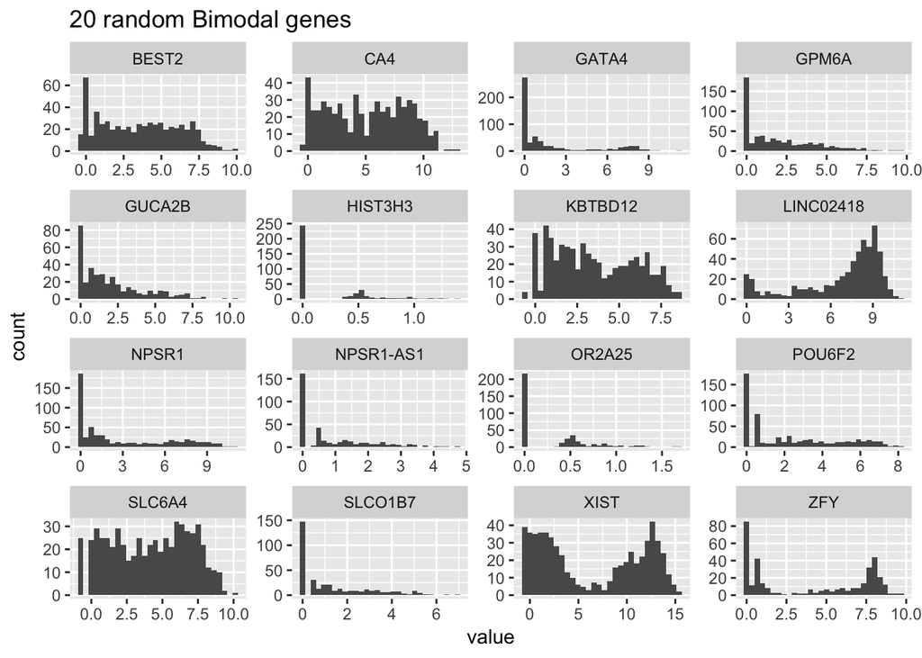

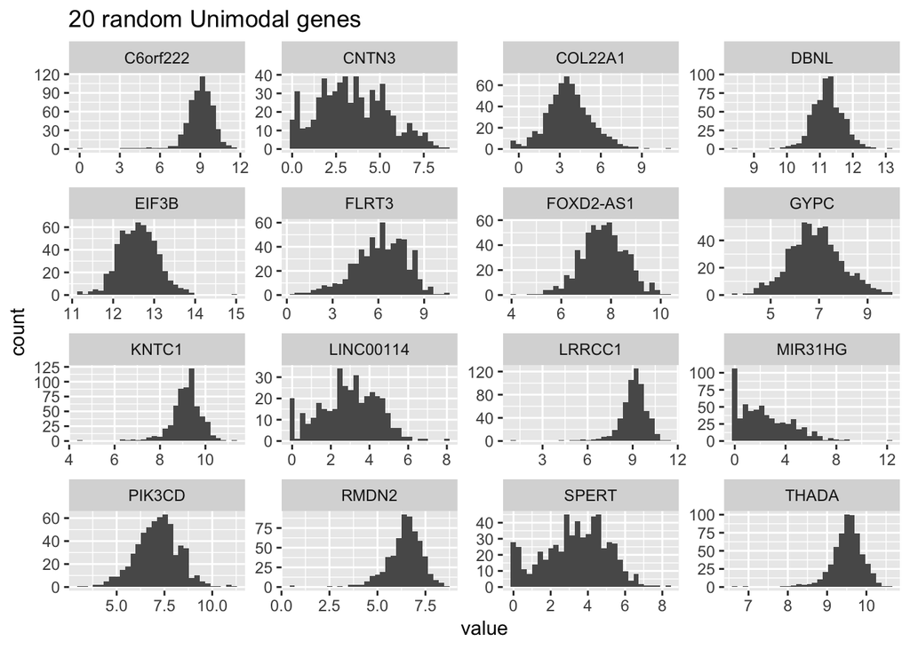

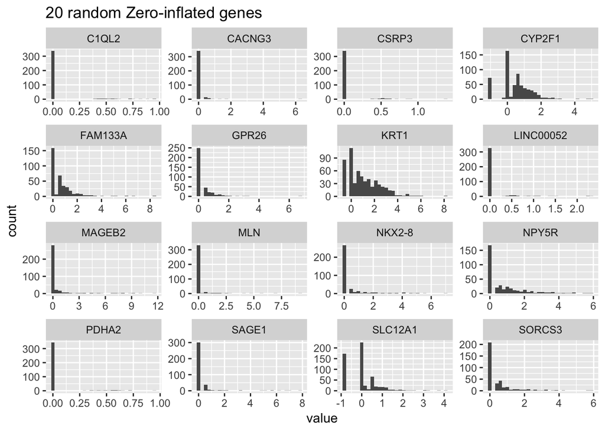

And depending on the distribution category, we can perform binarization:

```
## [1] "Bimodal example:"
```

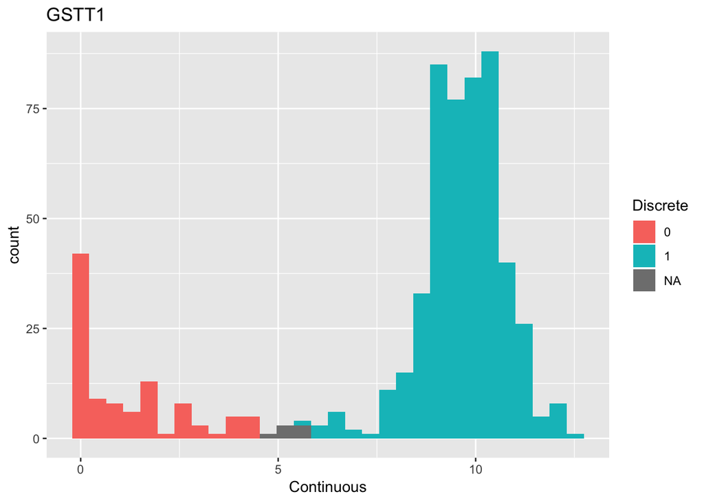

```
## [1] "Unimodal example:"
```

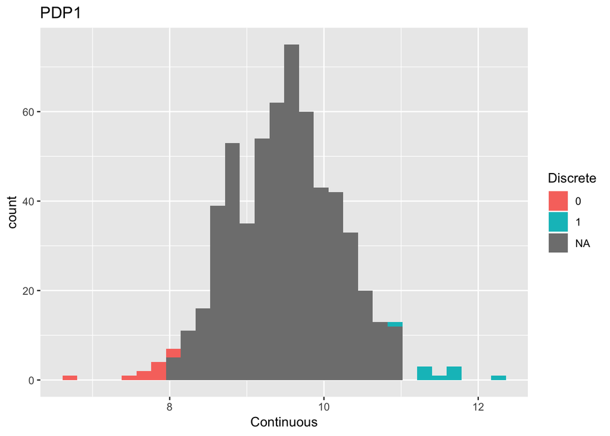

```
## [1] "ZeroInf example:"
```

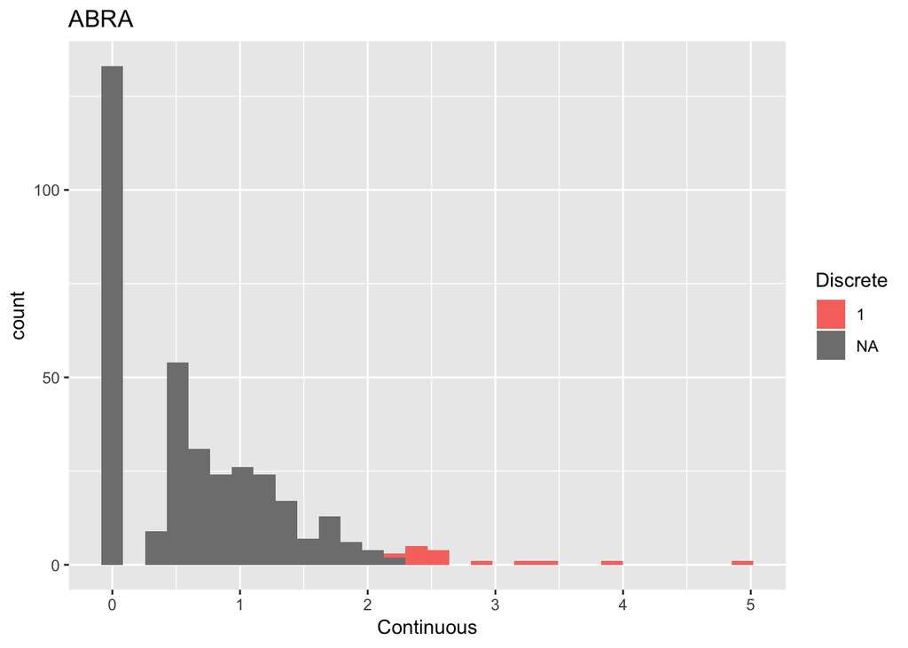

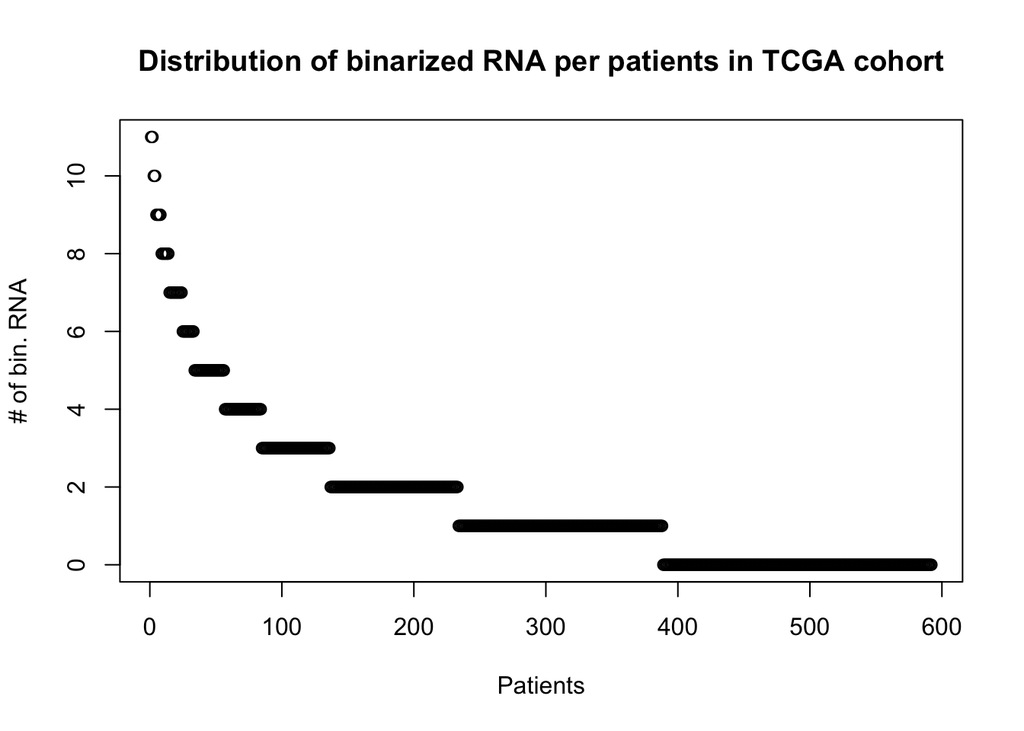

[figure not shown]

#### Normalization

Note that, in the nomenclature of the files, unless explicitly stated with the mention _norm, the data is binarized.

```
## [1] "Bimodal example:"
```

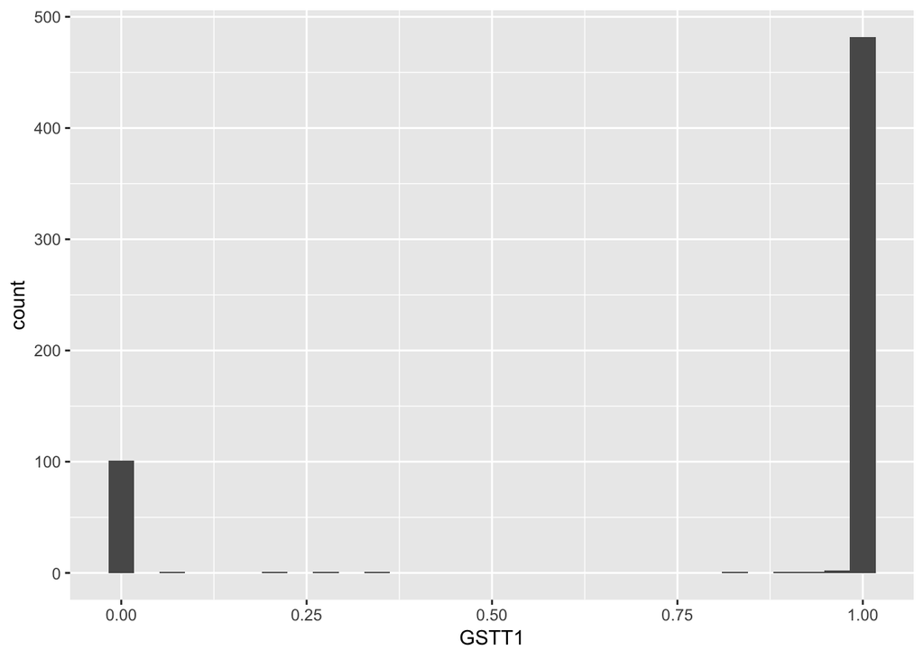

```
## [1] "Unimodal example:"
```

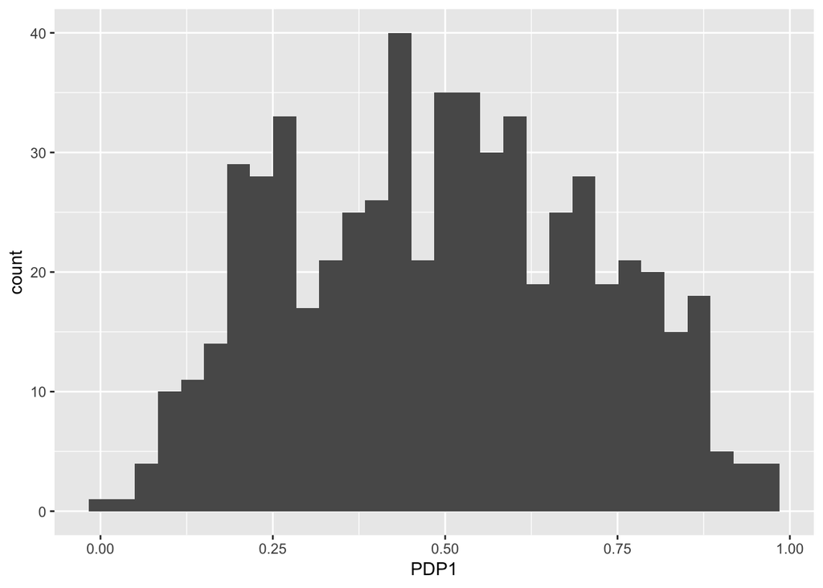

```
## [1] "ZeroInf example:"
```

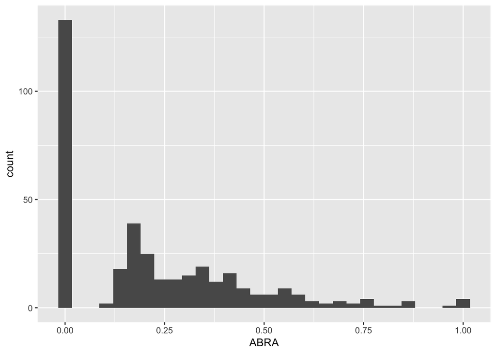

## Merged profiles

### Data types relations

Before merging independent profiles into multi-omics profiles, let’s have a look at relations between data types

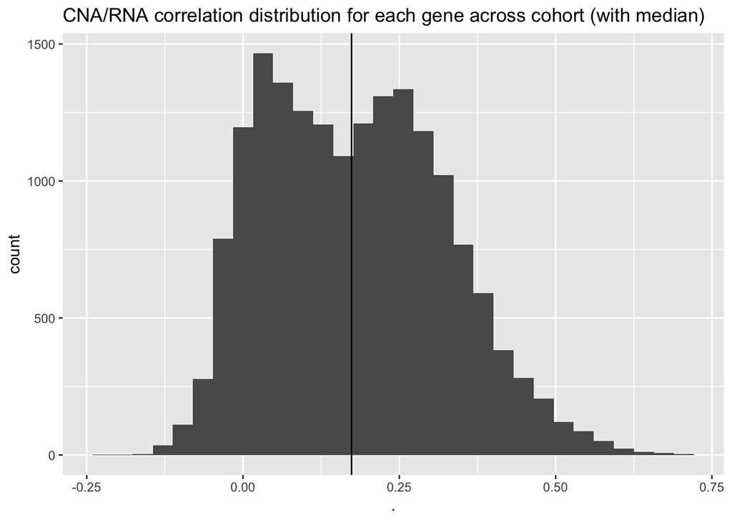

#### Mutations and CNA

In particular, is there any mutation/CNA binary inconsistency?

```
## [1] "No mutation/CNA binary inconsistencies"
```

In case of ambiguity, pritority is given to mutations over CNA

#### CNA and RNA

| Patient | Gene | CNA | RNA |
| --- | --- | --- | --- |
| TCGA-AA-A01S-01 | SNAI2 | 1 | 0 |
| TCGA-A6-A566-01 | ZEB2 | 0 | 1 |

## Write profiles

The profiles are exported as csv files.